# BIOS545 Spring 2015 Week 4 Lab 2: Functions and Debugging

Pittard wsp@emory.edu ***

## FUNCTIONS AND SCOPE

PRACTICE 1.0) NOTE THAT YOUR DEFAULT R SESSIONS RUNS IN A GLOBAL ENVIRONMENT

```r
environment()
```

```
## <environment: R_GlobalEnv>
```

```r
ls() # What is in your current environment ? Anything interesting ?
```

```
## character(0)
```

```r
# Don't do the following unless you want to remove all objects in the current
# environment

rm(list=ls())
```

PRACTICE 1.1) FUNCTIONS ALSO RUN WITHIN THEIR OWN ENVIROMENT

```r
environment()
```

```
## <environment: R_GlobalEnv>
```

```r
# Functions run within their own "frame" and evironment

myenvfunc <- function() {
   print(environment())
}

myenvfunc()
```

```
## <environment: 0x7fdbc58f5e38>
```

PRACTICE 1.2) VARIABLES WITHIN A FUNCTION WILL “MASK” VARIABLES OF THE SAME NAME IN THE GLOBAL ENVIRONMENT

```r
x <- 0      # Set x to zero in the global environment (your console)

myfunc <- function(x) {     # Define this function
   x <- 3                    # This value of "x" is private
   return(x)
}

myfunc()       # Function returns 3
```

```
## [1] 3
```

```r
x              # The value of x does not get overwritten
```

```
## [1] 0
```

PRACTICE 1.3) LET’S LOOK AT VARIABLE SCOPE

```r
exampf <- function(x) {
   return(x + a)
}

a <- 10
x <- 5

ls()
```

```
## [1] "a"         "exampf"    "myenvfunc" "myfunc"    "x"
```

```r
exampf(2)
```

```
## [1] 12
```

PRACTICE 1.4) LET’S LOOK AT VARIABLE SCOPE WHEN WE HAVE TWO FUNCTIONS DEFINED WITHIN THE GLOBAL ENVIRONMENT. THEY ARE “PEER” FUNCTIONS.

```r
a <- 10

x <- 5

f <- function(x) {
     a <- 5
     g(x)
}

g <- function(y) {
    return(y + a)
}

f(2)
```

```
## [1] 12
```

PRACTICE 1.5) NEXT WE LOOK AT A SCOPE FOR A FUNCTION THAT IS DEFINED WITHIN ANOTHER FUNCTION

```r
a <- 10

x <- 5

f <- function(x) {
    a <- 5
    g <- function(y) {
       return(y + a)
    }
    g(x)
}

f(2)
```

```
## [1] 7
```

PRACTICE 2.0) DON’T DEFINE A FUNCTION WITHIN ANOTHER FUNCTION IF YOU WANT THAT FUNCTION TO BE GENERALLY AVAILABLE.

```r
# This function is available within the global environment.

is.odd <- function(somenumber) {
   retval <- 0
   if (somenumber %% 2 != 0) {
       retval <- TRUE
   } else {
       retval <- FALSE
   }
   return(retval)
}
is.odd(3)
```

```
## [1] TRUE
```

```r
# However, if you define is.odd within another function, mymedian, it will not be available except within the scope of mymedian

mymedian <- function(medianvec) {

  is.odd <- function(somenumber) {  # We define is.odd inside of mymedian
    retval <- 0
    if (somenumber %% 2 != 0) {
        retval <- TRUE
    } else {
        retval <- FALSE
    }
    return(retval)
  }

# Function to compute the median of a vector

  medianveclength <- length(medianvec)
  if (is.odd(medianveclength)) {

     # We find the median using the formula for odd length vectors

  } else {

     # We find the median using the formula for even length vectors

  }
}
```

PRACTICE 2.1) THE ORDER IN WHICH WE SUPPLY THE ARGUMENTS DOES MATTER. THIS IS CALLED POSITIONAL MATCHING.

```r
pythag <- function(a = 4, b = 5) {
     if (!is.numeric(a) | !is.numeric(b)) {
        stop("I need real values to make this work")
     }
     hypo <- sqrt(a^2 + b^2)
     myreturnlist <- list(hypoteneuse = hypo, sidea = a, sideb = b)
     return(myreturnlist)
}

# IF WE CALL THE FUNCTION LIKE THIS:

pythag(4,5)  # 4 is assigned to a and 5 is assigned to b
```

```
## $hypoteneuse
## [1] 6.403124
##
## $sidea
## [1] 4
##
## $sideb
## [1] 5
```

```r
pythag(5,4)  # 5 is assigned to a and 4 is assigned to b
```

```
## $hypoteneuse
## [1] 6.403124
##
## $sidea
## [1] 5
##
## $sideb
## [1] 4
```

PRACTICE 2.2) THE MEAN FUNCTION CAN ACCOMMODATE A NUMBER OF ARGUMENTS.

```r
set.seed(1)

myx <- rnorm(20)

mean(myx)       # myx MATCHES the "x" argument
```

```
## [1] 0.1905239
```

```r
mean(myx,0.05) # myx MATCHES "x" and 0.05 MATCHES "trim"
```

```
## [1] 0.2461054
```

```r
mean(myx,0.05,TRUE) # myx MATCHES "x", 0.05 MATCHES "trim", TRUE matches na.rm
```

```
## [1] 0.2461054
```

```r
# COULD DO:

mean(x = myx, trim = 0.05, na.rm = TRUE)
```

```
## [1] 0.2461054
```

```r
# As long as you name the arguments you type them in any order

mean(trim = 0.05, na.rm = TRUE, x = myx)
```

```
## [1] 0.2461054
```

PRACTICE 2.3) IF YOU DON’T SPECIFY ARGUEMENT NAMES YOU MUST ADHERE TO THE EXPECTED ORDER:

```r
# BUT THIS WON'T WORK:

# Can't switch positions without using the names

mean(TRUE,0.05,myx)
```

```
## [1] 1
```

PRACTICE 3.0) THE … ARGUEMNT LET’S US PASS IN ADDITIONAL UNDEFINED ARGUEMENTS TO A FUNCTION - AS LONG AS THEY MAKE SENSE. THE PLOT FUNCTION ACCOMMODATES A VERY LARGE NUMBER ARGUEMENTS.

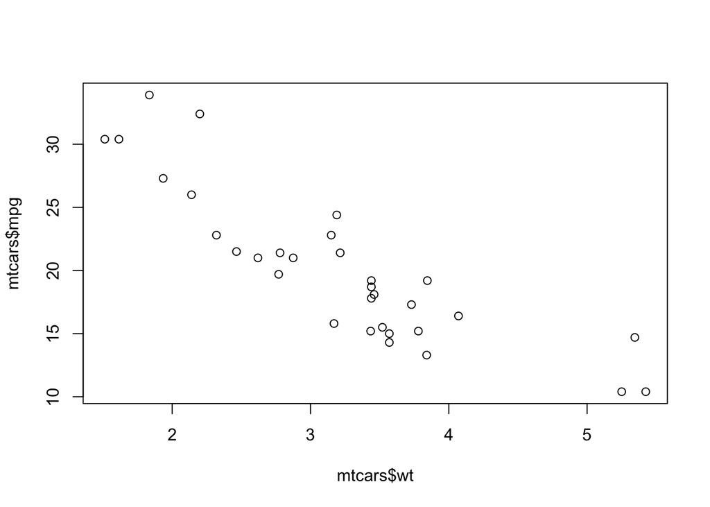

```r
plot(x=mtcars$wt,y=mtcars$mpg)
```

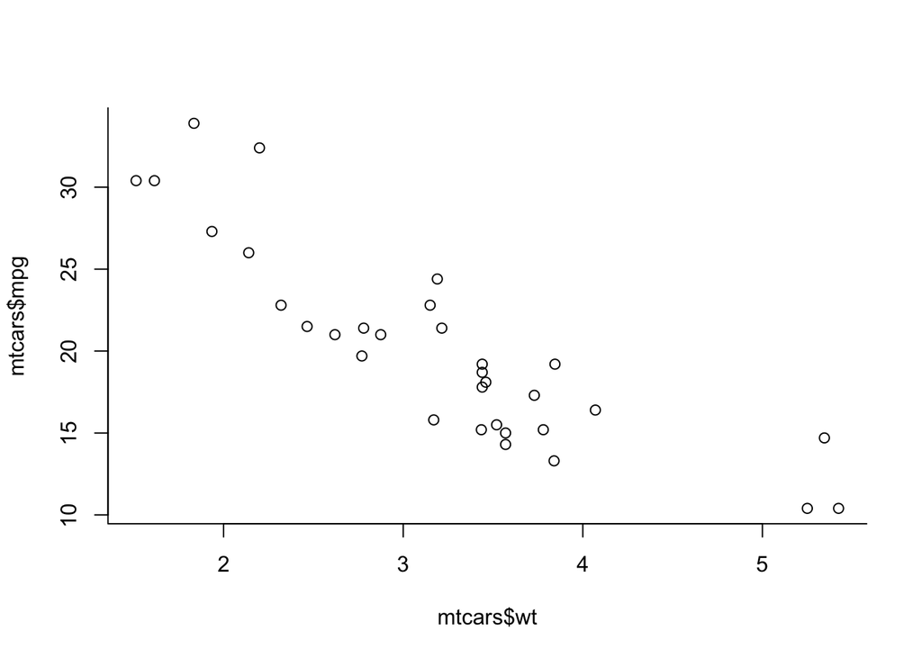

```r
plot(x=mtcars$wt,y=mtcars$mpg, bty="l")
```

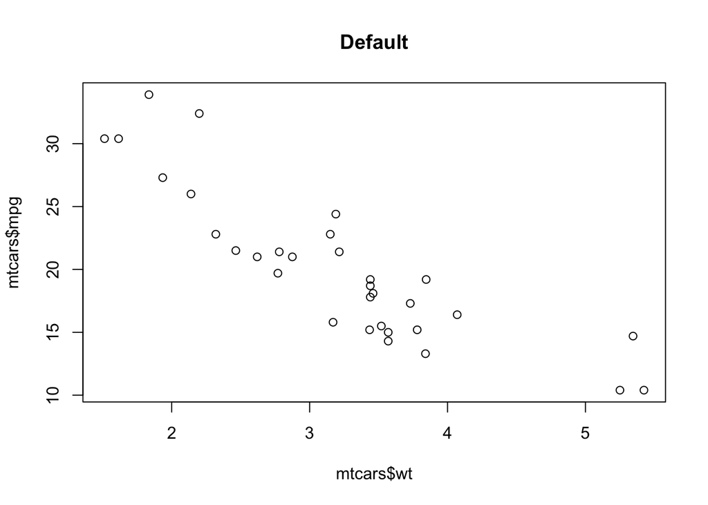

```r
plot(x=mtcars$wt,y=mtcars$mpg, main="Default")
```

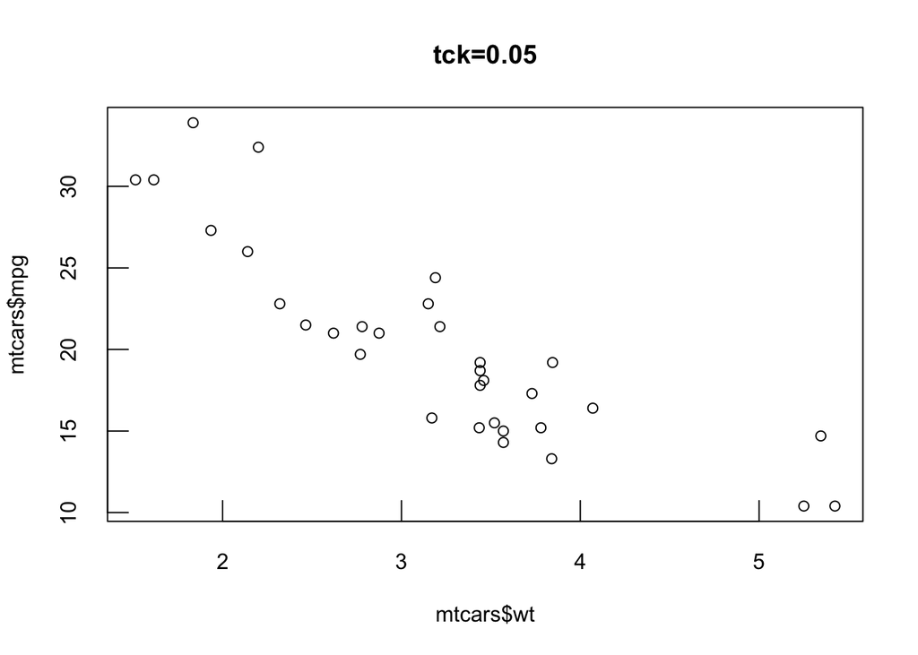

```r
plot(x=mtcars$wt,y=mtcars$mpg, tck=0.05, main="tck=0.05")
```

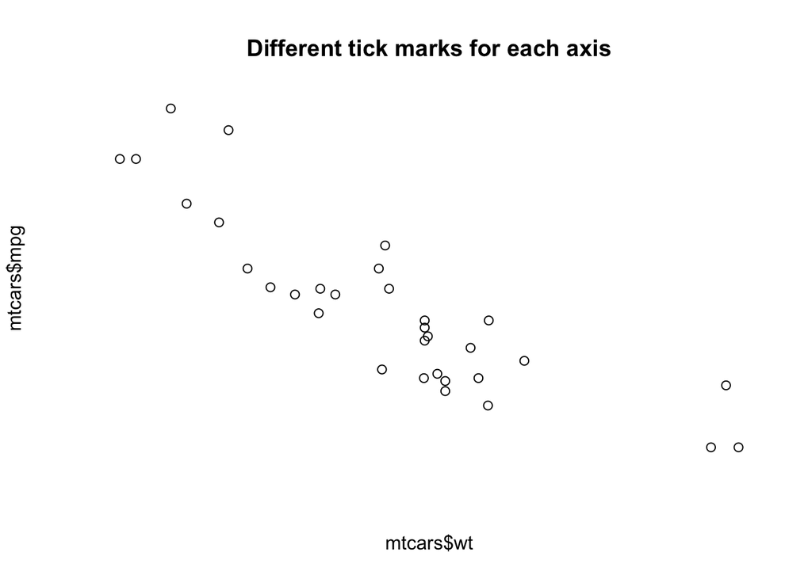

```r
plot(x=mtcars$wt,y=mtcars$mpg, axes=F, main="Different tick marks for each axis")
```

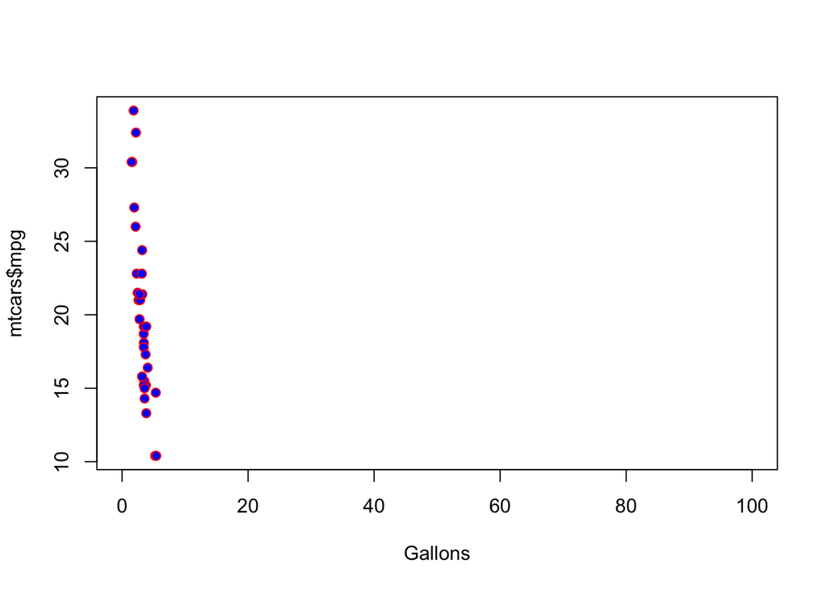

```r
plot(x=mtcars$wt,y=mtcars$mpg,xlim=c(0,100),xlab="Gallons",pch=21,bg="blue",col="red")
```

***

PRACTICE 3.1) THE … ARGUEMNT LET’S US PASS IN ADDITIONAL UNDEFINED ARGUEMENTS TO A FUNCTION - AS LONG AS THEY MAKE SENSE. THE PLOT FUNCTION ACCOMMODATES A VERY LARGE NUMBER ARGUEMENTS.

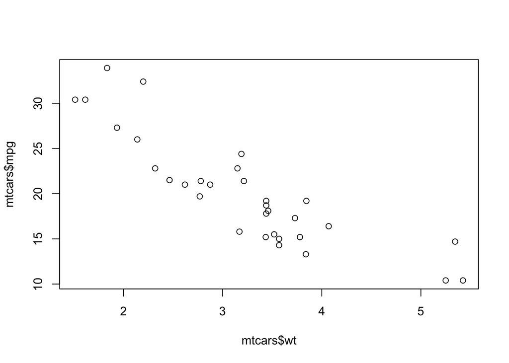

```r
plot(x=mtcars$wt,y=mtcars$mpg)
```

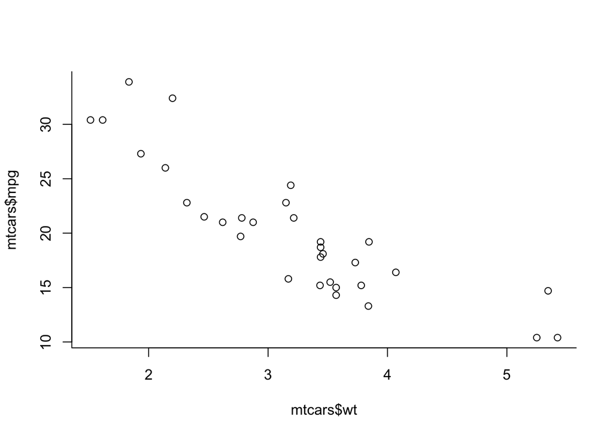

```r
plot(x=mtcars$wt,y=mtcars$mpg, bty="l")
```

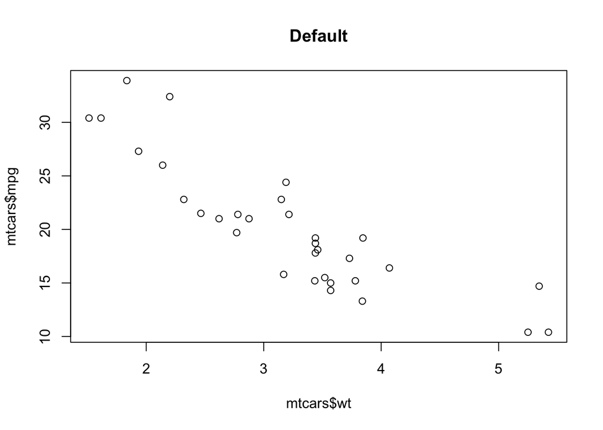

```r
plot(x=mtcars$wt,y=mtcars$mpg, main="Default")
```

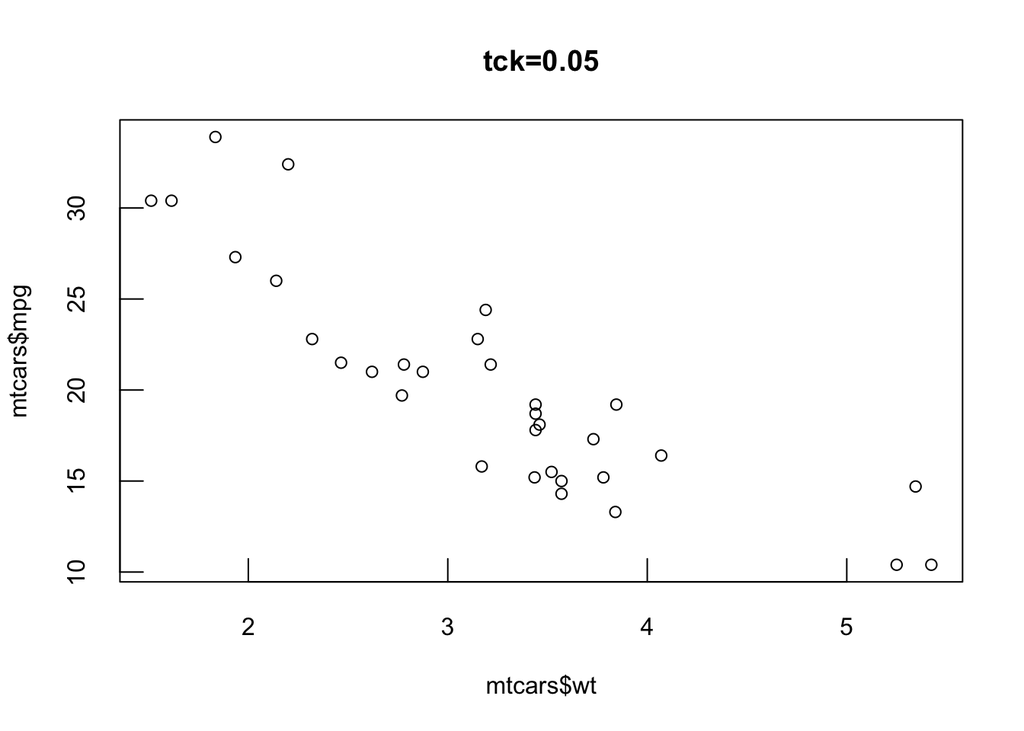

```r
plot(x=mtcars$wt,y=mtcars$mpg, tck=0.05, main="tck=0.05")
```

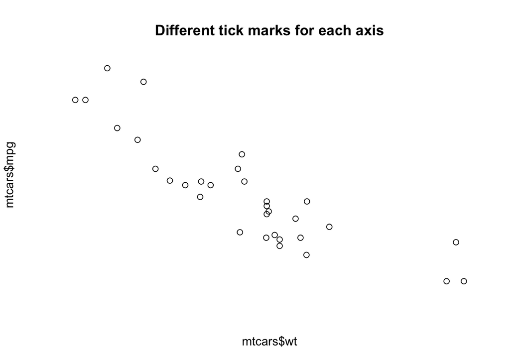

```r
plot(x=mtcars$wt,y=mtcars$mpg, axes=F, main="Different tick marks for each axis")
```

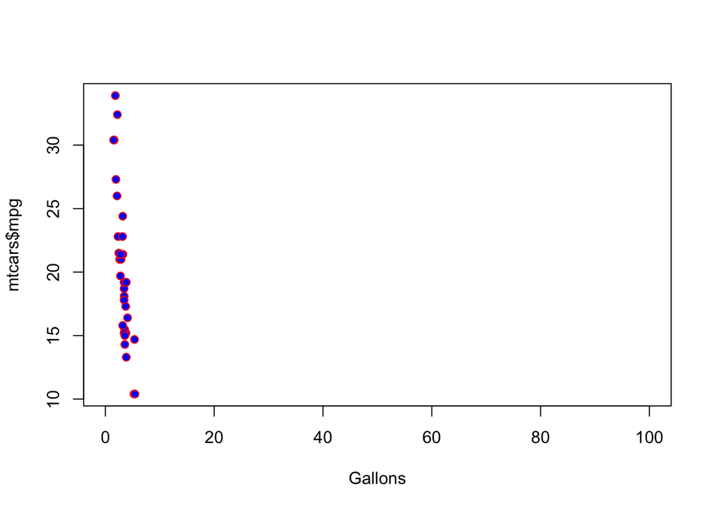

```r
plot(x=mtcars$wt,y=mtcars$mpg,xlim=c(0,100),xlab="Gallons",pch=21,bg="blue",col="red")
```

***

PRACTICE 3.2) USING THE … ARGUMENT WE CAN “THROW” ARGUMENTS AT THE PLOT FUNCTION.

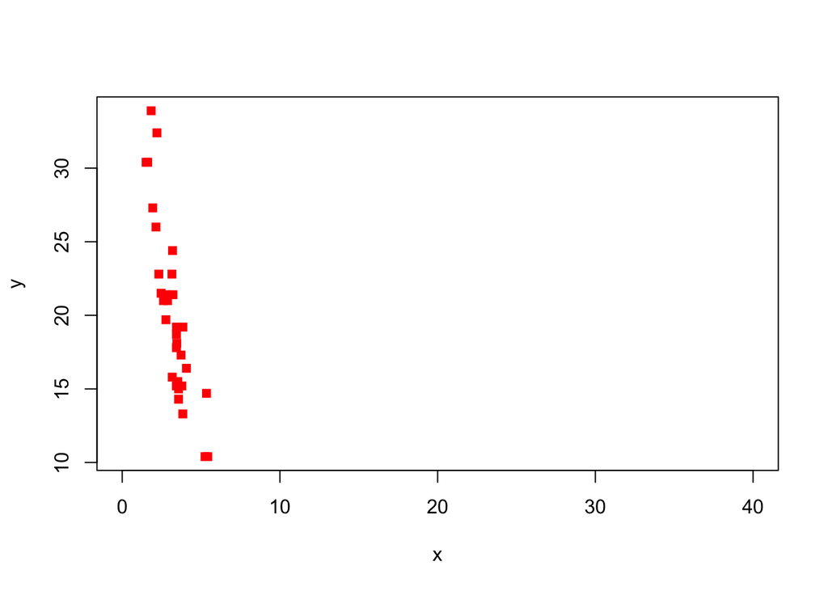

```r
my.plot <- function(x,y, ...) {
  plot(x,y, col="red",...)
}

my.plot(x=mtcars$wt, y=mtcars$mpg, pch=15, lty=2, xlim=c(0,40))
```

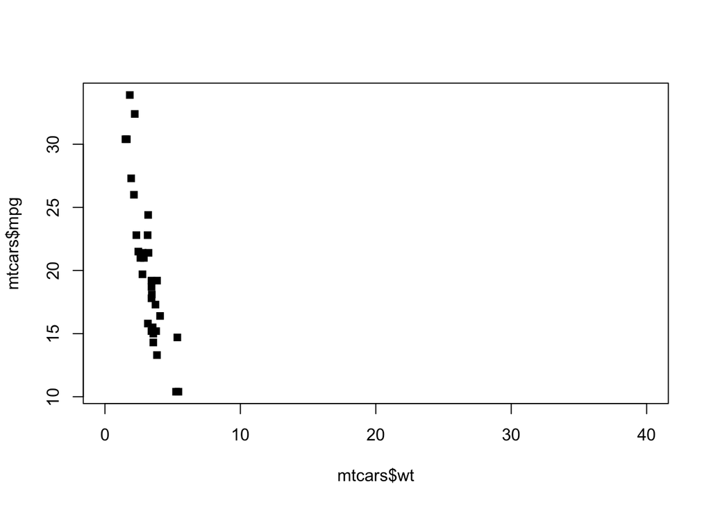

```r
my.plot <- function(...) {
  plot(...)
}

my.plot(x=mtcars$wt, y=mtcars$mpg, pch=15, lty=2, xlim=c(0,40))
```

***

PRACTICE 4.0) DEBUGGING FUNCTIONS IS AN IMPORTANT SKILL. USUALLY WE INSERT PRINT OR CAT STATEMENTS. BUT THIS IS A LIMITED APPROACH.

```r
my.func <- function(x,y) {
  if (!is.numeric(x) || !is.numeric(y) ) {
      warning("Check your input")
  }
      cat("x is",x,"y is",y,"\n")
      z <- x + y
      return(z)
}

# my.func(1,"2")  # Will produce an error
```

PRACTICE 4.1) USING TRACEBACK WILL SHOW US THE “STACK” (ORDER) OF FUNCTION CALLS AS WELL AS RELEVANT LINE NUMBERS.

```r
foo <- function(x) {
    print(1)
    bar(2)
}

bar <- function(x) {
    x + some.nonexistent.variable
}

foo(2) # This will generate an error

traceback()  # SHOWS US THE PROBLEM
```

PRACTICE 4.2) THIS EXAMPLE IS MORE INVOLVED. FIRST WE WILL SHOW A CASE WHERE THE FUNCTIONS DO NOT GENERATE AN ERROR.

```r
f <- function(x) {
  r <- x - g(x)
  return(r)
}

g <- function(y) {
  r <- y * h(y)
  return(r)
}

h <- function(x) {
  r <- log(x)
  if(r < 10)
     return(r^2)
  else
     return(r^3)
}

f(2)
```

```
## [1] 1.039094
```

PRACTICE 4.3) HERE WE GENERATE AN ERROR INTENTIONALLY.

```r
f <- function(x) {
  r <- x - g(x)
  return(r)
}

g <- function(y) {
  r <- y * h(y)
  return(r)
}

h <- function(x) {
  r <- log(x)
  if(r < 10)
     return(r^2)
  else
     return(r^3)
}

# f(-1)  This will bomb

traceback() # This will show us the sequence of calls that led to the error.
```

```
## No traceback available
```

PRACTICE 4.4) BUT WE CAN USE THE DEBUG FUNCTION ALSO. LET’S START USING A BASIC EXAMPLE:

```r
SS <- function(mu, x) {    # Compute Sum of Squares
  d <- x - mu
    d2 <- d^2
    ss <- sum(d2)
    return(ss)
}

# Set the seed so that the results are reproducible


set.seed(100)

x = rnorm(100)

SS(1,x)

debug(SS)

SS  # Starts a debug session
i
Browse[2]> d[1]
[1] -1.502192

Browse[2]> n
debug at #4: ss <- sum(d2)

Browse[2]> ls()
[1] "d"  "d2" "mu" "x"

Browse[2]> hist(d2)  # Can do this on the fly

Browse[2]> n
debug at #5: ss

Browse[2]> ls()
[1] "d"  "d2" "mu" "ss" "x"

Browse[2]> length(ss)
[1] 1

Browse[2]> ss

Browse[2]> yy = x ^2   # Create a New Object

Browse[2]> yy[1]
[1] 0.2521972

Browse[2]> where                # Where are we ? Oh yea in SS
where 1: SS(1, x)

Browse[2]> c                            # Continue without stopping

exiting from: SS(1, x)
[1] 202.5615

undebug(SS)           # Turns off debugging
```

PRACTICE 4.5) LET’s LOOK AT AN EXAMPLE WITH NESTED FUNCTION CALLING:

```r
f <- function(x) {
  r <- x - g(x)
  r
}

g <- function(y) {
  r <- y * h(y)
  r
}

h <- function(x) {
  r <- log(x)
  if(r < 10)
     r^2
  else
     r^3
}

debug(f)

debug(g)

debug(h)

f(-1)
debugging in: f(-1)
debug at #1: {
    r <- x - g(x)
    r
}

Browse[2]> where   # Tells us where we are
where 1: f(-1)

Browse[2]> n
debug at #2: r <- x - g(x)

Browse[2]> n            # Note we are "stepping into g"
debugging in: g(x)
debug at #1: {
    r <- y * h(y)
    r
}

Browse[3]> n
debug at #2: r <- y * h(y)

Browse[3]> n            # Note we are "stepping into h"
debugging in: h(y)
debug at #1: {
    r <- log(x)
    if (r < 10)
        r^2
    else r^3
}

Browse[4]> n
debug at #2: r <- log(x)

Browse[4]> n
debug at #3: if (r < 10) r^2 else r^3

Browse[4]> n

Error in if (r < 10) r^2 else r^3 : missing value where TRUE/FALSE needed
In addition: Warning message:
In log(x) : NaNs produced
```

PRACTICE 4.6) LET’s LOOK AT AN EXAMPLE WITH TRACE:

```r
f <- function(x) {
  r <- x - g(x)
  r
}

g <- function(y) {
  r <- y * h(y)
  r
}

h <- function(x) {
  r <- log(x)
  if(r < 10)
     r^2
  else
     r^3
}

as.list(body(h))   # Get function body with line number

# Put in the trace code that will be invoked if NaNs are detected

trace("h", quote( if(is.nan(r)) { recover() } ), at = 3, print = F)

body(h)     # See the trace code


f(-10)
```